# Homework 8

Joshua Carpenter

## Data and Description

**NOTE: For this assignment, you do not need to make your graphs/plots look “pretty”, meaning you do not need to worry about changing the axis limits, relabeling axes, etc.**

Bike sharing systems are the new generation of traditional bike rentals where the process from membership, rental and return back has become automatic. Through these systems, users are able to easily rent a bike from a particular position and return back at another position. Currently, there are about over 500 bikesharing programs around the world which is composed of over 500,000 bicycles. Today, there exists great interest in these systems due to their important role in traffic, environmental and health issues.

The bike-sharing rental process is highly correlated with environmental and seasonal settings. For instance, weather conditions, precipitation, day of week, season, hour of the day, etc. can affect the volume of rentals. This dataset is composed from the two-year historical data corresponding to years 2011 and 2012 from the Capital Bikeshare system in Washington D.C. The daily counts of the number of bikes used was extracted and then the corresponding weather and seasonal information was added.

The data set has information for 731 days and contains the following variables:

| Variable | Description |
| --- | --- |
| season | Season (Fall, Spring, Summer, Winter) |
| yr | Year (2011, 2012) |
| holiday | Was the day a holiday (Yes/No)? |
| workingday | Was the day a working day (Yes/No)? (Yes if the day is neither a weekend nor a holiday) |
| weathersit | Weather (Clear, Light Precip, Misty) |
| temp | Normalized temperature in Celsius |
| hum | Normalized humidity |
| windspeed | Normalized windspeed |
| cnt | Number of bikes rented |

The data can be found in the Bikes data set on Canvas. Download Bikes.csv, and put it in the same folder as this R Markdown file.

#### 0. Replace the text “< PUT YOUR NAME HERE >” (above next to “author:”) with your full name.

#### 1. Read in the data set, and call the data frame “bikes”. Make sure the yr and character variables are factors (if they are not, you’ll need to make them factors). Print a summary of the data and make sure the data makes sense.

```r
bikes <- read.csv("Bikes.csv", stringsAsFactors = TRUE) %>%
  as_tibble()
```

#### 2. Explore the data: create a histogram for the response. *Briefly describe the shape of the distribution - you should mention (1) symmetry or skewness, (2) the number of modes, and (3) potential outliers.*

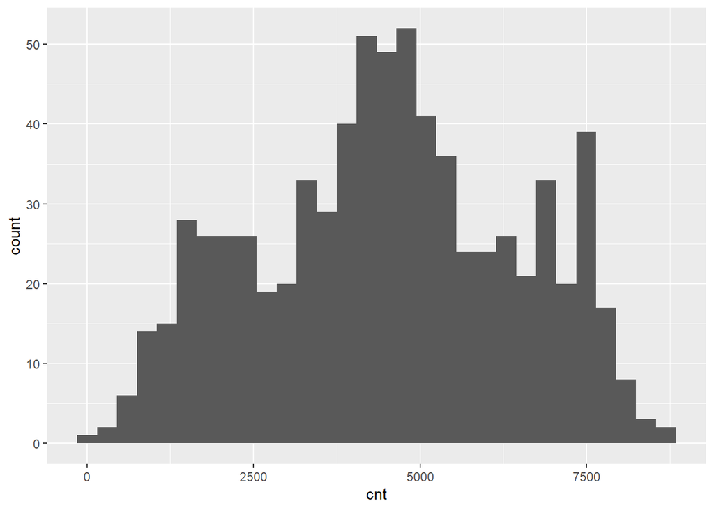

```r
ggplot(data = bikes, mapping = aes(x = cnt)) +
  geom_histogram()
```

The data is symmetric with one clear mode and maybe two others. There are no clear outliers.